# R Notebook

```r
library(data.table)
library(magrittr)
library(tidyr)
```

# Section 1

Hint: You can solve parts 1, 2 and 3 by looking at the printed output. You do not need to load the datasets.

1. Visually examine the dataset AirPassengers. Which of the following is true:
1. AirPassengers is tidy data: it has one year for each row.
2. AirPassengers is not tidy: we need at least one column with a character vector.
3. AirPassengers is not tidy: it is a matrix instead of a data frame. -> d. AirPassengers is not tidy: to be tidy we would have to wrangle it to have three columns (year, month and value), then each passenger count would have a row.
2. Visually examine the dataset ChickWeight. Which of the following is true:
1. ChickWeight is not tidy: each chick has more than one row. -> b. ChickWeight is tidy: each observation (a weight) is represented by one row. The chick from which this measurement came is one of the variables.
2. ChickWeight is not tidy: we are missing the year column.
3. ChickWeight is tidy: it is stored in a data frame.
3. Visually examine the dataset spanish_vowels. Is the data set tidy? No Label can be split
4. The example_product_data.csv file describes the number of times a person bought product “a” and “b”. Load the file into a data.table.

```r
product_dt <- fread("./extdata/example_product_data.csv")
product_dt
```

| name | producta | productb |
| --- | --- | --- |
| John Doe | NA | 12 |
| Marry Doe | 3 | 1 |
| John Johnson | 5 | 1 |

5. Transform product_dt into a long format using data.table commands.

```r
long_dt <- melt(product_dt, id.vars = "name", measure.vars = c("producta", "productb"), variable.name = "product", value.name = "count")
long_dt <- melt(product_dt, id.vars = "name", variable.name = "product", value.name = "count")
long_dt
```

| name | product | count |
| --- | --- | --- |
| John Doe | producta | NA |
| Marry Doe | producta | 3 |
| John Johnson | producta | 5 |
| John Doe | productb | 12 |
| Marry Doe | productb | 1 |
| John Johnson | productb | 1 |

6. Transform the table from the long format back into a wide format. Check that it is equal to the original data.table.

```r
dcast(long_dt, ... ~ product, value.var = "count")
```

| name | producta | productb |
| --- | --- | --- |
| John Doe | NA | 12 |
| John Johnson | 5 | 1 |
| Marry Doe | 3 | 1 |

# Section 02 - Merge Warm Up

Prepare two tables by running the following code:

```r
mtcars_dt <- as.data.table(mtcars)
mtcars_dt[, carname := rownames(mtcars)]
dt1 <- mtcars_dt[5:25,.(carname, mpg, cyl)]
dt2 <- mtcars_dt[1:10, .(carname, gear)]

dt1
```

| carname | mpg | cyl |
| --- | --- | --- |
| Hornet Sportabout | 18.7 | 8 |
| Valiant | 18.1 | 6 |
| Duster 360 | 14.3 | 8 |
| Merc 240D | 24.4 | 4 |
| Merc 230 | 22.8 | 4 |
| Merc 280 | 19.2 | 6 |
| Merc 280C | 17.8 | 6 |
| Merc 450SE | 16.4 | 8 |
| Merc 450SL | 17.3 | 8 |
| Merc 450SLC | 15.2 | 8 |

[output cut: 11 more lines]

```r
dt2
```

| carname | gear |
| --- | --- |
| Mazda RX4 | 4 |
| Mazda RX4 Wag | 4 |
| Datsun 710 | 4 |
| Hornet 4 Drive | 3 |
| Hornet Sportabout | 3 |
| Valiant | 3 |
| Duster 360 | 3 |
| Merc 240D | 4 |
| Merc 230 | 4 |
| Merc 280 | 4 |

1. How many rows does the inner merge of dt1 and dt2 have? 6
2. How many rows does the left merge of dt1 and dt2 have? 21
3. How many rows does the outer merge of dt1 and dt2 have? 25

```r
merge(dt1, dt2, by = "carname")
```

| carname | mpg | cyl | gear |
| --- | --- | --- | --- |
| Duster 360 | 14.3 | 8 | 3 |
| Hornet Sportabout | 18.7 | 8 | 3 |
| Merc 230 | 22.8 | 4 | 4 |
| Merc 240D | 24.4 | 4 | 4 |
| Merc 280 | 19.2 | 6 | 4 |
| Valiant | 18.1 | 6 | 3 |

```r
# or all = FALSE

merge(dt1, dt2, by = "carname", all.x = TRUE)
```

| carname | mpg | cyl | gear |
| --- | --- | --- | --- |
| AMC Javelin | 15.2 | 8 | NA |
| Cadillac Fleetwood | 10.4 | 8 | NA |
| Camaro Z28 | 13.3 | 8 | NA |
| Chrysler Imperial | 14.7 | 8 | NA |
| Dodge Challenger | 15.5 | 8 | NA |
| Duster 360 | 14.3 | 8 | 3 |
| Fiat 128 | 32.4 | 4 | NA |
| Honda Civic | 30.4 | 4 | NA |
| Hornet Sportabout | 18.7 | 8 | 3 |
| Lincoln Continental | 10.4 | 8 | NA |

[output cut: 11 more lines]

```r
merge(dt1, dt2, by = "carname", all = TRUE)
```

| carname | mpg | cyl | gear |
| --- | --- | --- | --- |
| AMC Javelin | 15.2 | 8 | NA |
| Cadillac Fleetwood | 10.4 | 8 | NA |
| Camaro Z28 | 13.3 | 8 | NA |
| Chrysler Imperial | 14.7 | 8 | NA |
| Datsun 710 | NA | NA | 4 |
| Dodge Challenger | 15.5 | 8 | NA |
| Duster 360 | 14.3 | 8 | 3 |
| Fiat 128 | 32.4 | 4 | NA |
| Honda Civic | 30.4 | 4 | NA |
| Hornet 4 Drive | NA | NA | 3 |

[output cut: 15 more lines]

# Section 03 - Weather dataset

1. Read in the weather dataset weather.txt as a data.table. Please find this file on Moodle and save it to a folder called extdata in your working directory.

```r
weather_dt <- fread("./extdata/weather.txt")
weather_dt
```

| id | year | month | element | d1 | d2 | d3 | d4 | d5 | d6 | d7 | d8 | d9 | d10 | d11 | d12 | d13 | d14 | d15 | d16 | d17 | d18 | d19 | d20 | d21 | d22 | d23 | d24 | d25 | d26 | … |
| --- | --- | --- | --- | --- | --- | --- | --- | --- | --- | --- | --- | --- | --- | --- | --- | --- | --- | --- | --- | --- | --- | --- | --- | --- | --- | --- | --- | --- | --- | --- |
| MX000017004 | 2010 | 1 | TMAX | NA | NA | NA | NA | NA | NA | NA | NA | NA | NA | NA | NA | NA | NA | NA | NA | NA | NA | NA | NA | NA | NA | NA | NA | NA | NA | … |
| MX000017004 | 2010 | 1 | TMIN | NA | NA | NA | NA | NA | NA | NA | NA | NA | NA | NA | NA | NA | NA | NA | NA | NA | NA | NA | NA | NA | NA | NA | NA | NA | NA | … |
| MX000017004 | 2010 | 2 | TMAX | NA | 273 | 241 | NA | NA | NA | NA | NA | NA | NA | 297 | NA | NA | NA | NA | NA | NA | NA | NA | NA | NA | NA | 299 | NA | NA | NA | … |
| MX000017004 | 2010 | 2 | TMIN | NA | 144 | 144 | NA | NA | NA | NA | NA | NA | NA | 134 | NA | NA | NA | NA | NA | NA | NA | NA | NA | NA | NA | 107 | NA | NA | NA | … |
| MX000017004 | 2010 | 3 | TMAX | NA | NA | NA | NA | 321 | NA | NA | NA | NA | 345 | NA | NA | NA | NA | NA | 311 | NA | NA | NA | NA | NA | NA | NA | NA | NA | NA | … |
| MX000017004 | 2010 | 3 | TMIN | NA | NA | NA | NA | 142 | NA | NA | NA | NA | 168 | NA | NA | NA | NA | NA | 176 | NA | NA | NA | NA | NA | NA | NA | NA | NA | NA | … |
| MX000017004 | 2010 | 4 | TMAX | NA | NA | NA | NA | NA | NA | NA | NA | NA | NA | NA | NA | NA | NA | NA | NA | NA | NA | NA | NA | NA | NA | NA | NA | NA | NA | … |
| MX000017004 | 2010 | 4 | TMIN | NA | NA | NA | NA | NA | NA | NA | NA | NA | NA | NA | NA | NA | NA | NA | NA | NA | NA | NA | NA | NA | NA | NA | NA | NA | NA | … |
| MX000017004 | 2010 | 5 | TMAX | NA | NA | NA | NA | NA | NA | NA | NA | NA | NA | NA | NA | NA | NA | NA | NA | NA | NA | NA | NA | NA | NA | NA | NA | NA | NA | … |
| MX000017004 | 2010 | 5 | TMIN | NA | NA | NA | NA | NA | NA | NA | NA | NA | NA | NA | NA | NA | NA | NA | NA | NA | NA | NA | NA | NA | NA | NA | NA | NA | NA | … |

[output cut: 12 more lines]

2. Why is this dataset messy? Different days are seperate col names Also many NA values
3. How would a tidy version of it look like? Do not give the code, only describe how the tidy table would look like. Add another col called day and have it contain the value of the (1-31)
4. Create a tidy version of the weather dataset.

```r
better_weather_dt <- na.omit(melt(weather_dt, id.vars = c("id", "year", "month", "element"), variable.name = "day", value.name = "temperature"))
better_weather_dt
```

| id | year | month | element | day | temperature |
| --- | --- | --- | --- | --- | --- |
| MX000017004 | 2010 | 12 | TMAX | d1 | 299 |
| MX000017004 | 2010 | 12 | TMIN | d1 | 138 |
| MX000017004 | 2010 | 2 | TMAX | d2 | 273 |
| MX000017004 | 2010 | 2 | TMIN | d2 | 144 |
| MX000017004 | 2010 | 11 | TMAX | d2 | 313 |
| MX000017004 | 2010 | 11 | TMIN | d2 | 163 |
| MX000017004 | 2010 | 2 | TMAX | d3 | 241 |
| MX000017004 | 2010 | 2 | TMIN | d3 | 144 |
| MX000017004 | 2010 | 7 | TMAX | d3 | 286 |
| MX000017004 | 2010 | 7 | TMIN | d3 | 175 |

[output cut: 56 more lines]

```r
better_weather_dt[, day:=substr(day, 2, length(day))]
better_weather_dt
```

| id | year | month | element | day | temperature |
| --- | --- | --- | --- | --- | --- |
| MX000017004 | 2010 | 12 | TMAX | 1 | 299 |
| MX000017004 | 2010 | 12 | TMIN | 1 | 138 |
| MX000017004 | 2010 | 2 | TMAX | 2 | 273 |
| MX000017004 | 2010 | 2 | TMIN | 2 | 144 |
| MX000017004 | 2010 | 11 | TMAX | 2 | 313 |
| MX000017004 | 2010 | 11 | TMIN | 2 | 163 |
| MX000017004 | 2010 | 2 | TMAX | 3 | 241 |
| MX000017004 | 2010 | 2 | TMIN | 3 | 144 |
| MX000017004 | 2010 | 7 | TMAX | 3 | 286 |
| MX000017004 | 2010 | 7 | TMIN | 3 | 175 |

[output cut: 56 more lines]

```r
better_weather_dt <- dcast(better_weather_dt, ... ~ element, value.var = "temperature")
better_weather_dt
```

| id | year | month | day | TMAX | TMIN |
| --- | --- | --- | --- | --- | --- |
| MX000017004 | 2010 | 1 | 30 | 278 | 145 |
| MX000017004 | 2010 | 2 | 11 | 297 | 134 |
| MX000017004 | 2010 | 2 | 2 | 273 | 144 |
| MX000017004 | 2010 | 2 | 23 | 299 | 107 |
| MX000017004 | 2010 | 2 | 3 | 241 | 144 |
| MX000017004 | 2010 | 3 | 10 | 345 | 168 |
| MX000017004 | 2010 | 3 | 16 | 311 | 176 |
| MX000017004 | 2010 | 3 | 5 | 321 | 142 |
| MX000017004 | 2010 | 4 | 27 | 363 | 167 |
| MX000017004 | 2010 | 5 | 27 | 332 | 182 |

[output cut: 23 more lines]

```r
better_weather_dt <- better_weather_dt[, .(id, day, month, year, TMAX, TMIN)]
better_weather_dt
```

| id | day | month | year | TMAX | TMIN |
| --- | --- | --- | --- | --- | --- |
| MX000017004 | 30 | 1 | 2010 | 278 | 145 |
| MX000017004 | 11 | 2 | 2010 | 297 | 134 |
| MX000017004 | 2 | 2 | 2010 | 273 | 144 |
| MX000017004 | 23 | 2 | 2010 | 299 | 107 |
| MX000017004 | 3 | 2 | 2010 | 241 | 144 |
| MX000017004 | 10 | 3 | 2010 | 345 | 168 |
| MX000017004 | 16 | 3 | 2010 | 311 | 176 |
| MX000017004 | 5 | 3 | 2010 | 321 | 142 |
| MX000017004 | 27 | 4 | 2010 | 363 | 167 |
| MX000017004 | 27 | 5 | 2010 | 332 | 182 |

[output cut: 23 more lines]

```r
# I feel this is not needed but it is done in the example
better_weather_dt <- better_weather_dt[, .(id, date=paste(day, month, year, sep = "/"), TMAX, TMIN)]
better_weather_dt
```

| id | date | TMAX | TMIN |
| --- | --- | --- | --- |
| MX000017004 | 30/1/2010 | 278 | 145 |
| MX000017004 | 11/2/2010 | 297 | 134 |
| MX000017004 | 2/2/2010 | 273 | 144 |
| MX000017004 | 23/2/2010 | 299 | 107 |
| MX000017004 | 3/2/2010 | 241 | 144 |
| MX000017004 | 10/3/2010 | 345 | 168 |
| MX000017004 | 16/3/2010 | 311 | 176 |
| MX000017004 | 5/3/2010 | 321 | 142 |
| MX000017004 | 27/4/2010 | 363 | 167 |
| MX000017004 | 27/5/2010 | 332 | 182 |

[output cut: 23 more lines]

# Section 04 -Scattered data across many files

The baby-names folder contains 258 csv-files (1999.girl.csv, 1999.boy.csv , . . . ) which store name frequencies for a particular year and sex.

1. Create a list containing all file paths in the folder, i.e. (extdata/baby-names/1999.girl.csv, extdata/baby-names/1999.boys.csv, . . . ). Refer to Appendix A of the script if you are having trouble with the file paths.

```r
paths <- list()

for(year in 1880:2008) {
  paths <- append(paths, file.path("extdata", "baby-names", paste(year, ".boy.csv", sep = "") ))
  paths <- append(paths, file.path("extdata", "baby-names", paste(year, ".girl.csv", sep = "") ))
}

# Better way of doing this
paths <- list.files("extdata/baby-names", full.names=TRUE)
paths
```

```
  [1] "extdata/baby-names/1880.boy.csv"  "extdata/baby-names/1880.girl.csv" "extdata/baby-names/1881.boy.csv"
  [4] "extdata/baby-names/1881.girl.csv" "extdata/baby-names/1882.boy.csv"  "extdata/baby-names/1882.girl.csv"
  [7] "extdata/baby-names/1883.boy.csv"  "extdata/baby-names/1883.girl.csv" "extdata/baby-names/1884.boy.csv"
 [10] "extdata/baby-names/1884.girl.csv" "extdata/baby-names/1885.boy.csv"  "extdata/baby-names/1885.girl.csv"
 [13] "extdata/baby-names/1886.boy.csv"  "extdata/baby-names/1886.girl.csv" "extdata/baby-names/1887.boy.csv"
 [16] "extdata/baby-names/1887.girl.csv" "extdata/baby-names/1888.boy.csv"  "extdata/baby-names/1888.girl.csv"
 [19] "extdata/baby-names/1889.boy.csv"  "extdata/baby-names/1889.girl.csv" "extdata/baby-names/1890.boy.csv"
 [22] "extdata/baby-names/1890.girl.csv" "extdata/baby-names/1891.boy.csv"  "extdata/baby-names/1891.girl.csv"
 [25] "extdata/baby-names/1892.boy.csv"  "extdata/baby-names/1892.girl.csv" "extdata/baby-names/1893.boy.csv"
 [28] "extdata/baby-names/1893.girl.csv" "extdata/baby-names/1894.boy.csv"  "extdata/baby-names/1894.girl.csv"
 [31] "extdata/baby-names/1895.boy.csv"  "extdata/baby-names/1895.girl.csv" "extdata/baby-names/1896.boy.csv"
 [34] "extdata/baby-names/1896.girl.csv" "extdata/baby-names/1897.boy.csv"  "extdata/baby-names/1897.girl.csv"
 [37] "extdata/baby-names/1898.boy.csv"  "extdata/baby-names/1898.girl.csv" "extdata/baby-names/1899.boy.csv"
 [40] "extdata/baby-names/1899.girl.csv" "extdata/baby-names/1900.boy.csv"  "extdata/baby-names/1900.girl.csv"
 [43] "extdata/baby-names/1901.boy.csv"  "extdata/baby-names/1901.girl.csv" "extdata/baby-names/1902.boy.csv"
```

[output cut: 71 more lines]

2. Name the list entries with the basename of the corresponding file path. The basename of a path is the actual name of the file, e.g. the basename of extdata/baby-names/1999.girl.csv is 1999.girl.csv.

```r
names(paths) <- basename(paths)
paths
```

```
                      1880.boy.csv                      1880.girl.csv                       1881.boy.csv                      1881.girl.csv
 "extdata/baby-names/1880.boy.csv" "extdata/baby-names/1880.girl.csv"  "extdata/baby-names/1881.boy.csv" "extdata/baby-names/1881.girl.csv"
                      1882.boy.csv                      1882.girl.csv                       1883.boy.csv                      1883.girl.csv
 "extdata/baby-names/1882.boy.csv" "extdata/baby-names/1882.girl.csv"  "extdata/baby-names/1883.boy.csv" "extdata/baby-names/1883.girl.csv"
                      1884.boy.csv                      1884.girl.csv                       1885.boy.csv                      1885.girl.csv
 "extdata/baby-names/1884.boy.csv" "extdata/baby-names/1884.girl.csv"  "extdata/baby-names/1885.boy.csv" "extdata/baby-names/1885.girl.csv"
                      1886.boy.csv                      1886.girl.csv                       1887.boy.csv                      1887.girl.csv
 "extdata/baby-names/1886.boy.csv" "extdata/baby-names/1886.girl.csv"  "extdata/baby-names/1887.boy.csv" "extdata/baby-names/1887.girl.csv"
                      1888.boy.csv                      1888.girl.csv                       1889.boy.csv                      1889.girl.csv
 "extdata/baby-names/1888.boy.csv" "extdata/baby-names/1888.girl.csv"  "extdata/baby-names/1889.boy.csv" "extdata/baby-names/1889.girl.csv"
                      1890.boy.csv                      1890.girl.csv                       1891.boy.csv                      1891.girl.csv
 "extdata/baby-names/1890.boy.csv" "extdata/baby-names/1890.girl.csv"  "extdata/baby-names/1891.boy.csv" "extdata/baby-names/1891.girl.csv"
                      1892.boy.csv                      1892.girl.csv                       1893.boy.csv                      1893.girl.csv
 "extdata/baby-names/1892.boy.csv" "extdata/baby-names/1892.girl.csv"  "extdata/baby-names/1893.boy.csv" "extdata/baby-names/1893.girl.csv"
                      1894.boy.csv                      1894.girl.csv                       1895.boy.csv                      1895.girl.csv
 "extdata/baby-names/1894.boy.csv" "extdata/baby-names/1894.girl.csv"  "extdata/baby-names/1895.boy.csv" "extdata/baby-names/1895.girl.csv"
                      1896.boy.csv                      1896.girl.csv                       1897.boy.csv                      1897.girl.csv
 "extdata/baby-names/1896.boy.csv" "extdata/baby-names/1896.girl.csv"  "extdata/baby-names/1897.boy.csv" "extdata/baby-names/1897.girl.csv"
                      1898.boy.csv                      1898.girl.csv                       1899.boy.csv                      1899.girl.csv
 "extdata/baby-names/1898.boy.csv" "extdata/baby-names/1898.girl.csv"  "extdata/baby-names/1899.boy.csv" "extdata/baby-names/1899.girl.csv"
                      1900.boy.csv                      1900.girl.csv                       1901.boy.csv                      1901.girl.csv
 "extdata/baby-names/1900.boy.csv" "extdata/baby-names/1900.girl.csv"  "extdata/baby-names/1901.boy.csv" "extdata/baby-names/1901.girl.csv"
                      1902.boy.csv                      1902.girl.csv                       1903.boy.csv                      1903.girl.csv
 "extdata/baby-names/1902.boy.csv" "extdata/baby-names/1902.girl.csv"  "extdata/baby-names/1903.boy.csv" "extdata/baby-names/1903.girl.csv"
                      1904.boy.csv                      1904.girl.csv                       1905.boy.csv                      1905.girl.csv
 "extdata/baby-names/1904.boy.csv" "extdata/baby-names/1904.girl.csv"  "extdata/baby-names/1905.boy.csv" "extdata/baby-names/1905.girl.csv"
                      1906.boy.csv                      1906.girl.csv                       1907.boy.csv                      1907.girl.csv
 "extdata/baby-names/1906.boy.csv" "extdata/baby-names/1906.girl.csv"  "extdata/baby-names/1907.boy.csv" "extdata/baby-names/1907.girl.csv"
                      1908.boy.csv                      1908.girl.csv                       1909.boy.csv                      1909.girl.csv
 "extdata/baby-names/1908.boy.csv" "extdata/baby-names/1908.girl.csv"  "extdata/baby-names/1909.boy.csv" "extdata/baby-names/1909.girl.csv"
                      1910.boy.csv                      1910.girl.csv                       1911.boy.csv                      1911.girl.csv
 "extdata/baby-names/1910.boy.csv" "extdata/baby-names/1910.girl.csv"  "extdata/baby-names/1911.boy.csv" "extdata/baby-names/1911.girl.csv"
                      1912.boy.csv                      1912.girl.csv                       1913.boy.csv                      1913.girl.csv
 "extdata/baby-names/1912.boy.csv" "extdata/baby-names/1912.girl.csv"  "extdata/baby-names/1913.boy.csv" "extdata/baby-names/1913.girl.csv"
                      1914.boy.csv                      1914.girl.csv                       1915.boy.csv                      1915.girl.csv
 "extdata/baby-names/1914.boy.csv" "extdata/baby-names/1914.girl.csv"  "extdata/baby-names/1915.boy.csv" "extdata/baby-names/1915.girl.csv"
                      1916.boy.csv                      1916.girl.csv                       1917.boy.csv                      1917.girl.csv
 "extdata/baby-names/1916.boy.csv" "extdata/baby-names/1916.girl.csv"  "extdata/baby-names/1917.boy.csv" "extdata/baby-names/1917.girl.csv"
                      1918.boy.csv                      1918.girl.csv                       1919.boy.csv                      1919.girl.csv
 "extdata/baby-names/1918.boy.csv" "extdata/baby-names/1918.girl.csv"  "extdata/baby-names/1919.boy.csv" "extdata/baby-names/1919.girl.csv"
```

[output cut: 75 more lines]

```
 "extdata/baby-names/1994.boy.csv" "extdata/baby-names/1994.girl.csv"  "extdata/baby-names/1995.boy.csv" "extdata/baby-names/1995.girl.csv"
                      1996.boy.csv                      1996.girl.csv                       1997.boy.csv                      1997.girl.csv
 "extdata/baby-names/1996.boy.csv" "extdata/baby-names/1996.girl.csv"  "extdata/baby-names/1997.boy.csv" "extdata/baby-names/1997.girl.csv"
                      1998.boy.csv                      1998.girl.csv                       1999.boy.csv                      1999.girl.csv
 "extdata/baby-names/1998.boy.csv" "extdata/baby-names/1998.girl.csv"  "extdata/baby-names/1999.boy.csv" "extdata/baby-names/1999.girl.csv"
                      2000.boy.csv                      2000.girl.csv                       2001.boy.csv                      2001.girl.csv
 "extdata/baby-names/2000.boy.csv" "extdata/baby-names/2000.girl.csv"  "extdata/baby-names/2001.boy.csv" "extdata/baby-names/2001.girl.csv"
                      2002.boy.csv                      2002.girl.csv                       2003.boy.csv                      2003.girl.csv
 "extdata/baby-names/2002.boy.csv" "extdata/baby-names/2002.girl.csv"  "extdata/baby-names/2003.boy.csv" "extdata/baby-names/2003.girl.csv"
                      2004.boy.csv                      2004.girl.csv                       2005.boy.csv                      2005.girl.csv
 "extdata/baby-names/2004.boy.csv" "extdata/baby-names/2004.girl.csv"  "extdata/baby-names/2005.boy.csv" "extdata/baby-names/2005.girl.csv"
                      2006.boy.csv                      2006.girl.csv                       2007.boy.csv                      2007.girl.csv
 "extdata/baby-names/2006.boy.csv" "extdata/baby-names/2006.girl.csv"  "extdata/baby-names/2007.boy.csv" "extdata/baby-names/2007.girl.csv"
                      2008.boy.csv                      2008.girl.csv
 "extdata/baby-names/2008.boy.csv" "extdata/baby-names/2008.girl.csv"
```

3. Read in the data from all files into one table. Hint: when you read many files and gather them into one table, be sure to add a column that identifies each file. rbindlist()

```r
tables <- lapply(paths, fread)

baby_names_dt <- rbindlist(tables, use.names = TRUE, idcol = "file_name")
baby_names_dt
```

| file_name | name | percent |
| --- | --- | --- |
| 1880.boy.csv | John | 0.081541 |
| 1880.boy.csv | William | 0.080511 |
| 1880.boy.csv | James | 0.050057 |
| 1880.boy.csv | Charles | 0.045167 |
| 1880.boy.csv | George | 0.043292 |
| 1880.boy.csv | Frank | 0.027380 |
| 1880.boy.csv | Joseph | 0.022229 |
| 1880.boy.csv | Thomas | 0.021401 |
| 1880.boy.csv | Henry | 0.020641 |
| 1880.boy.csv | Robert | 0.020404 |

[output cut: 990 more lines]

4. Is the data tidy? If not, tidy it up. No, gender and year can be split

```r
baby_names_dt <- as.data.table(separate(baby_names_dt, col = "file_name", into = c("year", "gender"), extra = "drop"))
baby_names_dt
```

| year | gender | name | percent |
| --- | --- | --- | --- |
| 1880 | boy | John | 0.081541 |
| 1880 | boy | William | 0.080511 |
| 1880 | boy | James | 0.050057 |
| 1880 | boy | Charles | 0.045167 |
| 1880 | boy | George | 0.043292 |
| 1880 | boy | Frank | 0.027380 |
| 1880 | boy | Joseph | 0.022229 |
| 1880 | boy | Thomas | 0.021401 |
| 1880 | boy | Henry | 0.020641 |
| 1880 | boy | Robert | 0.020404 |

[output cut: 990 more lines]

```r
baby_names_dt[, gender:=ifelse(gender=="boy", "M", "F") ]
baby_names_dt
```

| year | gender | name | percent |
| --- | --- | --- | --- |
| 1880 | M | John | 0.081541 |
| 1880 | M | William | 0.080511 |
| 1880 | M | James | 0.050057 |
| 1880 | M | Charles | 0.045167 |
| 1880 | M | George | 0.043292 |
| 1880 | M | Frank | 0.027380 |
| 1880 | M | Joseph | 0.022229 |
| 1880 | M | Thomas | 0.021401 |
| 1880 | M | Henry | 0.020641 |
| 1880 | M | Robert | 0.020404 |

[output cut: 990 more lines]

# Section 05 - Small case-study: cleaning up a gene-expression dataset in yeast

In this section, we will read and clean up the data from the paper: • Gagneur, Julien, et al. “Genotype-environment interactions reveal causal pathways that mediate genetic effects on phenotype.” PLoS Genet 9.9 (2013): e1003803. https://journals.plos.org/plosgenetics/artic le?id=10.1371/journal.pgen.1003803

You will not need to understand the data in depth for this exercise but if you are interested you can find a detailed description in section 7.1 of the script.

1. Read in the two files in the folder eqtl. The first file contains the genotypes of yeast strains and a strain identifyer. The second file contains information on how quickly each strain grows in different growth media.

```r
gt <- fread('extdata/eqtl/genotype.txt')
dim(gt)
```

```
[1]  158 1001
```

```r
head(gt[,1:5])
```

| strain | mrk_1 | mrk_14 | mrk_27 | mrk_40 |
| --- | --- | --- | --- | --- |
| seg_01B | Lab strain | Lab strain | Lab strain | Lab strain |
| seg_01C | Wild isolate | Wild isolate | Wild isolate | Wild isolate |
| seg_01D | Lab strain | Lab strain | Lab strain | Lab strain |
| seg_02B | Lab strain | Lab strain | Lab strain | Lab strain |
| seg_02C | Wild isolate | Wild isolate | Wild isolate | Lab strain |
| seg_02D | Lab strain | Lab strain | Lab strain | Wild isolate |

```r
gt
```

[output not shown]

[output cut: 990 more lines]

```r
growth <- fread('extdata/eqtl/growth.txt')
growth
```

| strain | YPD | YPD_BPS | YPD_Rapa | YPE | YPMalt |
| --- | --- | --- | --- | --- | --- |
| seg_01B | 12.603986 | 10.460795 | 2.500311 | 5.265698 | 6.720447 |
| seg_01C | 10.791144 | 11.632019 | NA | 5.365259 | 7.429273 |
| seg_01D | 12.817268 | 10.423287 | 3.142154 | 5.577932 | 6.905589 |
| seg_02B | 10.299210 | 9.103611 | 4.314388 | 3.257843 | 4.924324 |
| seg_02C | 11.132778 | 9.263100 | 3.548543 | 3.815689 | 4.413402 |
| seg_02D | 13.910836 | 11.750178 | NA | 5.672890 | 7.926200 |
| seg_03A | 11.186945 | 11.028460 | 3.466042 | 5.260072 | 8.885634 |
| seg_03C | 12.309580 | 9.788931 | NA | 4.724545 | 5.597243 |
| seg_03D | 11.462996 | 10.562557 | 4.830365 | 3.578990 | 5.003316 |
| seg_04B | 11.315445 | 10.716611 | 3.028480 | 3.971121 | 7.785617 |

[output cut: 148 more lines]

2. Come up with a strategy, how you can transform the two tables shown above into the single table shown below. head(dt) ## strain media growth_rate marker gt ## 1: seg_01B YPD 12.60399 mrk_1 Lab strain ## 2: seg_01B YPD 12.60399 mrk_14 Lab strain ## 3: seg_01B YPD 12.60399 mrk_27 Lab strain ## 4: seg_01B YPD 12.60399 mrk_40 Lab strain ## 5: seg_01B YPD 12.60399 mrk_54 Lab strain ## 6: seg_01B YPD 12.60399 mrk_67 Lab strain summary(dt) ## strain media growth_rate marker ## seg_01B: 5000 YPD :158000 Min. : 1.57 mrk_1 : 790 ## seg_01C: 5000 YPD_BPS :158000 1st Qu.: 4.55 mrk_14 : 790 ## seg_01D: 5000 YPD_Rapa:158000 Median : 6.93 mrk_27 : 790 ## seg_02B: 5000 YPE :158000 Mean : 7.60 mrk_40 : 790 ## seg_02C: 5000 YPMalt :158000 3rd Qu.:10.70 mrk_54 : 790 ## seg_02D: 5000 Max. :16.27 mrk_67 : 790 ## (Other):760000 NA’s :42000 (Other):785260 ## gt ## Lab strain :398145 ## Wild isolate:391855

```r
growth_long_dt <- melt(growth, id.vars = c("strain"), variable.name = "media", value.name = "growth_rate")
growth_long_dt
```

| strain | media | growth_rate |
| --- | --- | --- |
| seg_01B | YPD | 12.603986 |
| seg_01C | YPD | 10.791144 |
| seg_01D | YPD | 12.817268 |
| seg_02B | YPD | 10.299210 |
| seg_02C | YPD | 11.132778 |
| seg_02D | YPD | 13.910836 |
| seg_03A | YPD | 11.186945 |
| seg_03C | YPD | 12.309580 |
| seg_03D | YPD | 11.462996 |
| seg_04B | YPD | 11.315445 |

[output cut: 780 more lines]

```r
gt_long_dt <- melt(gt, id.vars = c("strain"), variable.name = "marker", value.name = "gt")
gt_long_dt
```

| strain | marker | gt |
| --- | --- | --- |
| seg_01B | mrk_1 | Lab strain |
| seg_01C | mrk_1 | Wild isolate |
| seg_01D | mrk_1 | Lab strain |
| seg_02B | mrk_1 | Lab strain |
| seg_02C | mrk_1 | Wild isolate |
| seg_02D | mrk_1 | Lab strain |
| seg_03A | mrk_1 | Wild isolate |
| seg_03C | mrk_1 | Wild isolate |
| seg_03D | mrk_1 | Lab strain |
| seg_04B | mrk_1 | Wild isolate |

[output cut: 990 more lines]

```r
merged_dt <- merge(growth_long_dt, gt_long_dt, by = "strain", allow.cartesian = TRUE)
merged_dt
```

| strain | media | growth_rate | marker | gt |
| --- | --- | --- | --- | --- |
| seg_01B | YPD | 12.60399 | mrk_1 | Lab strain |
| seg_01B | YPD | 12.60399 | mrk_14 | Lab strain |
| seg_01B | YPD | 12.60399 | mrk_27 | Lab strain |
| seg_01B | YPD | 12.60399 | mrk_40 | Lab strain |
| seg_01B | YPD | 12.60399 | mrk_54 | Lab strain |
| seg_01B | YPD | 12.60399 | mrk_67 | Lab strain |
| seg_01B | YPD | 12.60399 | mrk_80 | Lab strain |
| seg_01B | YPD | 12.60399 | mrk_94 | Lab strain |
| seg_01B | YPD | 12.60399 | mrk_107 | Lab strain |
| seg_01B | YPD | 12.60399 | mrk_120 | Lab strain |

[output cut: 990 more lines]

```r
merged_dt[,strain:=as.factor(strain)]
merged_dt[,gt:=as.factor(gt)]
merged_dt
```

| strain | media | growth_rate | marker | gt |
| --- | --- | --- | --- | --- |
| seg_01B | YPD | 12.60399 | mrk_1 | Lab strain |
| seg_01B | YPD | 12.60399 | mrk_14 | Lab strain |
| seg_01B | YPD | 12.60399 | mrk_27 | Lab strain |
| seg_01B | YPD | 12.60399 | mrk_40 | Lab strain |
| seg_01B | YPD | 12.60399 | mrk_54 | Lab strain |
| seg_01B | YPD | 12.60399 | mrk_67 | Lab strain |
| seg_01B | YPD | 12.60399 | mrk_80 | Lab strain |
| seg_01B | YPD | 12.60399 | mrk_94 | Lab strain |
| seg_01B | YPD | 12.60399 | mrk_107 | Lab strain |
| seg_01B | YPD | 12.60399 | mrk_120 | Lab strain |

[output cut: 990 more lines]

```r
summary(merged_dt)
```

```
     strain            media         growth_rate        marker                  gt
 seg_01B:  5000   YPD     :158000   Min.   : 1.57   mrk_1  :   790   Lab strain  :398145
 seg_01C:  5000   YPD_BPS :158000   1st Qu.: 4.55   mrk_14 :   790   Wild isolate:391855
 seg_01D:  5000   YPD_Rapa:158000   Median : 6.93   mrk_27 :   790
 seg_02B:  5000   YPE     :158000   Mean   : 7.60   mrk_40 :   790
 seg_02C:  5000   YPMalt  :158000   3rd Qu.:10.70   mrk_54 :   790
 seg_02D:  5000                     Max.   :16.27   mrk_67 :   790
 (Other):760000                     NA's   :42000   (Other):785260
```

3. Write code that implements your strategy to transform the two tables into the one shown above. (see above)
4. Spoiler: These are the things you can do with tidy data. When you are done run the following line of code and observe the result:

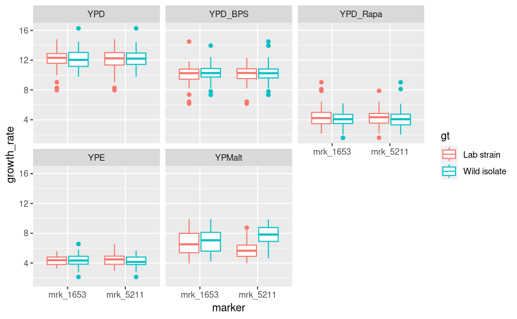

```r
library(ggplot2)

dt <- merged_dt
ggplot(dt[marker %in% c('mrk_5211', 'mrk_1653')], aes(marker, growth_rate, color=gt)) +
geom_boxplot() + facet_wrap(~media)
```